# Coursera-Machine-Learning

Dave

April 9, 2016

## Introduction

This analysis is related to the project assignment for the “Practical Machine Learning” course on coursera. Assignment background is as follows,

Using devices such as Jawbone Up, Nike FuelBand, and Fitbit it is now possible to collect a large amount of data about personal activity relatively inexpensively. These type of devices are part of the quantified self movement – a group of enthusiasts who take measurements about themselves regularly to improve their health, to find patterns in their behavior, or because they are tech geeks. One thing that people regularly do is quantify how much of a particular activity they do, but they rarely quantify how well they do it. In this project, your goal will be to use data from accelerometers on the belt, forearm, arm, and dumbell of 6 participants. They were asked to perform barbell lifts correctly and incorrectly in 5 different ways.

Submission criteria is as follows,

The goal of your project is to predict the manner in which they did the exercise. This is the “classe” variable in the training set. You may use any of the other variables to predict with. You should create a report describing how you built your model, how you used cross validation, what you think the expected out of sample error is, and why you made the choices you did. You will also use your prediction model to predict 20 different test cases.

# Packages

```r
library(randomForest)
```

```r
library(corrplot)
library(rpart)
library(rpart.plot)
```

# Reading data files

```r
trainingData <- read.csv("/Users/bhaveshdave/Desktop/Coursera/files/pml-training.csv")
testingData <- read.csv("/Users/bhaveshdave/Desktop/Coursera/files/pml-testing.csv")
```

# Data summary

Dimensions of training data and testing data are as follows

```r
set.seed(2016)
# training data
dim(trainingData)
```

```
## [1] 19622   160
```

```r
# testing data
dim(testingData)
```

```
## [1]  20 160
```

# Data cleanup

```r
trainingData <- trainingData[,colSums(is.na(trainingData)) == 0]
classe <- trainingData$classe
trainRemove <- grepl("^X|timestamp|window", names(trainingData))
trainingData <- trainingData[, !trainRemove]
trainCleaned <- trainingData[, sapply(trainingData, is.numeric)]
trainCleaned$classe <- classe
```

# Cleaned data summary

New dimension of cleaned training data is as follows

```r
dim(trainCleaned)
```

```
## [1] 19622    53
```

# Partitioning Data

Split the cleaned training data set into a training data set (75%) and testing data set (25%) for cross validation purpose

```r
inTrain <- createDataPartition(trainCleaned$classe, p= 0.75, list=FALSE)
training <- trainCleaned[inTrain,]
testing <- trainCleaned[-inTrain,]
```

# Creating Model & Summary of Model performance

Using random forrest algorithm we will fit a predictive model for activity

```r
modelRf <- randomForest(classe ~ ., data=training, ntree=250)
predictionRf <- predict(modelRf, testing, type = "class")
conMatrix <- confusionMatrix(predictionRf, testing$classe)

# Performance of this model on the validation dataset (testing set) is as follows
conMatrix
```

```
## Confusion Matrix and Statistics
##
##           Reference
## Prediction    A    B    C    D    E
##          A 1393    4    0    0    0
##          B    2  939    1    0    0
##          C    0    6  854    5    0
##          D    0    0    0  799    1
##          E    0    0    0    0  900
##
## Overall Statistics
##
##                Accuracy : 0.9961
##                  95% CI : (0.994, 0.9977)
##     No Information Rate : 0.2845
##     P-Value [Acc > NIR] : < 2.2e-16
##
##                   Kappa : 0.9951
##  Mcnemar's Test P-Value : NA
##
## Statistics by Class:
##
##                      Class: A Class: B Class: C Class: D Class: E
## Sensitivity            0.9986   0.9895   0.9988   0.9938   0.9989
## Specificity            0.9989   0.9992   0.9973   0.9998   1.0000
## Pos Pred Value         0.9971   0.9968   0.9873   0.9988   1.0000
## Neg Pred Value         0.9994   0.9975   0.9998   0.9988   0.9998
## Prevalence             0.2845   0.1935   0.1743   0.1639   0.1837
## Detection Rate         0.2841   0.1915   0.1741   0.1629   0.1835
## Detection Prevalence   0.2849   0.1921   0.1764   0.1631   0.1835
## Balanced Accuracy      0.9987   0.9944   0.9981   0.9968   0.9994
```

# Model fitting plot

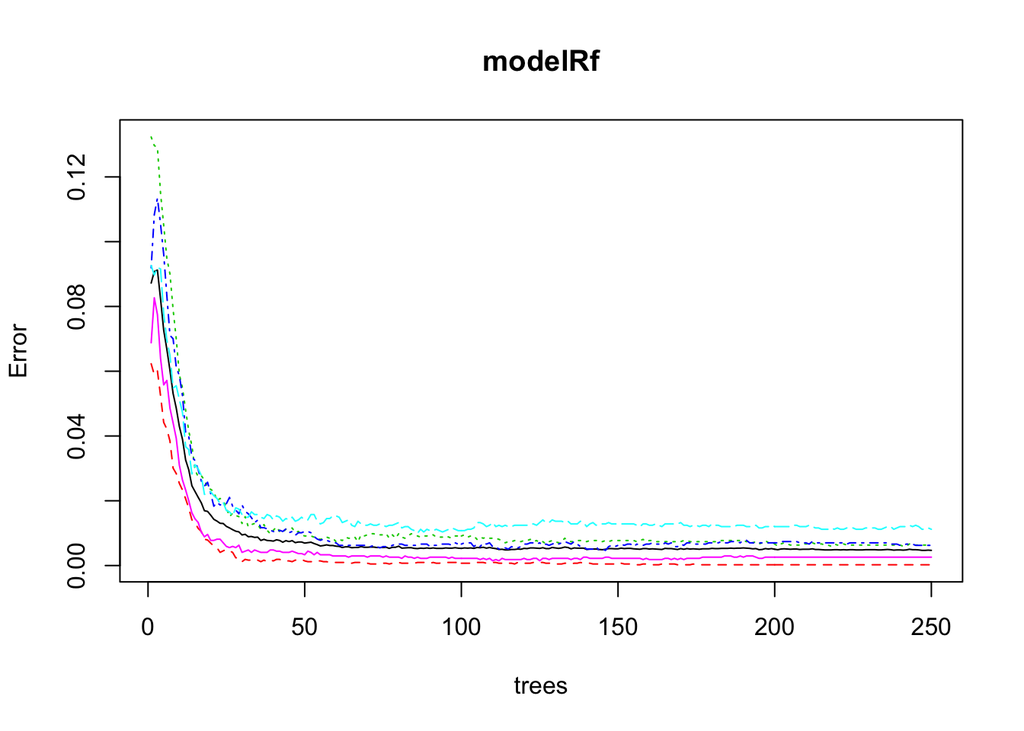

```r
plot(modelRf)
```

# Tree visualization

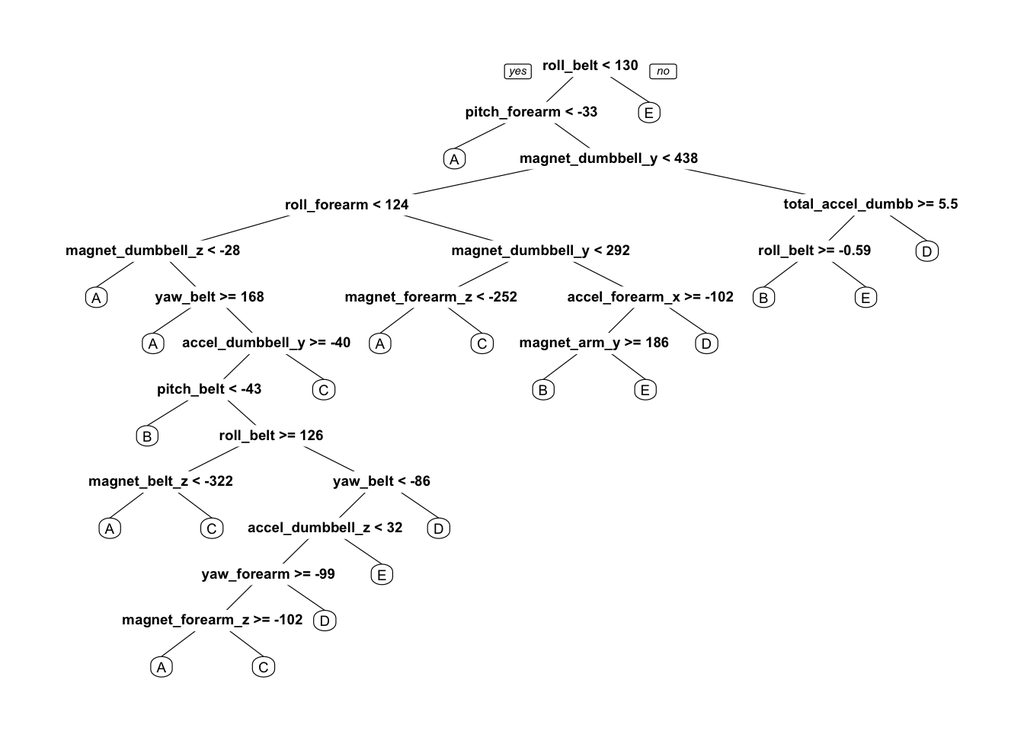

```r
tree <- rpart(classe~., data=training, method="class")
prp(tree)
```

# Applying model to the testing data

Applying the model to the original testing data set for assignment’s 20 cases result is as follows

```r
predictionOnTest <- predict(modelRf, testingData, type="class")
predictionOnTest
```

```
##  1  2  3  4  5  6  7  8  9 10 11 12 13 14 15 16 17 18 19 20
##  B  A  B  A  A  E  D  B  A  A  B  C  B  A  E  E  A  B  B  B
## Levels: A B C D E
```